# Road Traffic Accidents Data Analysis using R

Student ID: 201081646

# Introduction

This report is the second assessment of the **MATH5741M Statistical Theory and Methods** module. Its aim is to answer three questions through inferential statistical analysis regarding a road traffic accidents dataset from 2005 collected by the UK Department for Transport.

All the analysis has been done using **R** (programming language) and is code reproducible. To see the complete **R** coding process visit https://github.com/eugenividal/Road-Traffic-Accidents-Data-Analysis

# Results

## Question 1

In this question, first, we are asked to draw a boxplot to compare the number of vehicles involved in urban areas with the number involved in rural areas. Secondly, we have to carry out a test to investigate whether the average number of vehicles in an accident differs per type of area.

To plot the graph, we first remove the unallocated values.

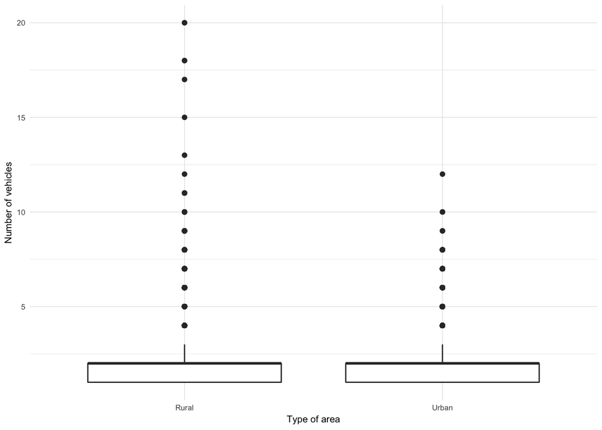

Number of vehicles involved grouped by type of area

Apart from the fact that rural areas have more ouliers than urban areas, we cannot appreciate differences between them. Both boxes are very similar and in both cases the median and upper quartile seem to be coincident.

From the table of values we can see that the data is very skewed to the right. Most values are between 1, 2 and 3.

| 1 | 2 | 3 | 4 | 5 | 6 | 7 | 8 | 9 | 10 | 11 | 12 | 13 | 15 | 17 | 18 | 20 |
| --- | --- | --- | --- | --- | --- | --- | --- | --- | --- | --- | --- | --- | --- | --- | --- | --- |
| 59770 | 117114 | 17002 | 3516 | 819 | 262 | 83 | 40 | 18 | 8 | 4 | 2 | 1 | 1 | 1 | 2 | 2 |

To improve this, we take the log10 of the Number of Vehicles variable and plot a second boxpot with this transformation.

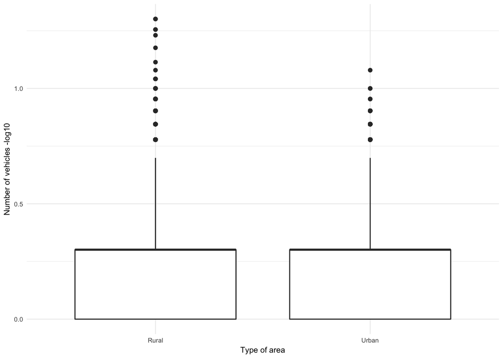

Number of vehicles (log10) involved grouped by type of area

This time the size of the boxes is bigger; however, we cannot be sure wheter the average number of vehicles involved differs per type of area.

To investigate this we carry out statistical test. The null hypothesis is both means are equal. The alternative hypothesis that they are different.

We will use a critical region approach with $\alpha$ = 0.01.

It seems reasonable to assume $\sigma_{1}^{2}$ = $\sigma_{2}^{2}$, so we apply a **pooled estimate**.

First, we calculate the pooled variance.

$$s_{p}^{2}=\frac{(n_{r}-1)s_{r}^{2}+(n_{u}-1)s_{u}^{2}}{n_{r}+n_{u}-2} = \frac{72266*0.03153835017+126377*0.02632197984}{72267+126378-2}=0.0282197$$

## Question 2

http://www.jbstatistics.com/chi-square-tests-for-one-way-tables/

## Question 3

Finally, in question 3, we are asked to compute a 95% confidence interval for the expected (mean) number of accidents which occur on a Monday.

We apply a simple t-distribution confidence interval. However, the sample is that big (n= 52) could be just compute a normal confidence interval.

```r
# Select data using only week-days
xx_mon<- xx%>%
  select(Day_of_Week, Date, count)%>%
  filter(Day_of_Week=="Monday")%>%
  group_by(Date)%>%
  summarise(n = sum(count))
```

```r
#t.test(Mondays, conf.level = 0.95)$conf.int
t.test(xx_mon$n)$conf.int
```

```
## [1] 508.9586 560.7337
## attr(,"conf.level")
## [1] 0.95
```

To apply this the assumptions are that (1) the sample is random and that the data is normally distributed.

```r
#t.test(Mondays, conf.level = 0.95)$conf.int
table2 <-table(as.data.frame(xx_mon$n))
kable(t(table2))
```

| 293 | 312 | 391 | 432 | 433 | 437 | 439 | 440 | 445 | 447 | 450 | 453 | 471 | 477 | 482 | 483 | 489 | 496 | 503 | 510 | 513 | 517 | 520 | 523 | 532 | 535 | 540 | 543 | 552 | 555 | … |
| --- | --- | --- | --- | --- | --- | --- | --- | --- | --- | --- | --- | --- | --- | --- | --- | --- | --- | --- | --- | --- | --- | --- | --- | --- | --- | --- | --- | --- | --- | --- |
| 1 | 1 | 1 | 1 | 1 | 1 | 1 | 1 | 1 | 1 | 1 | 1 | 1 | 1 | 1 | 1 | 1 | 1 | 1 | 1 | 1 | 1 | 2 | 1 | 1 | 1 | 1 | 1 | 1 | 1 | … |

# Bibliography

The resources used to carry out this project were:

- Balka, J. 2013. JBStatistics: Making Statistics Make Sense. Available from: http://www.jbstatistics.com.
- Lane, D.M. 2018. Online Statistics Education: An Interactive Multimedia Course of Study. Available from: http://onlinestatbook.com/.
- Taylor, C. 2017. MATH5741M: Statistical Theory and Methods. Outline Lecture Notes.
- Yau, C. 2018. R tutorial: an R introduction to statistics. Available from: http://www.r-tutor.com
[^1]: With this number of degrees of freedom we could have also apply the normal distribution